# Drug Sensitivity Prediction: CCLE Data Set

Amir Asiaee

22 January 2020

# 1 Executive Summary

## 1.1 Background

## 1.2 Methods

### 1.2.1 Input Data

### 1.2.2 Procedure

### 1.2.3 Output Data

### 1.2.4 Statistics

## 1.3 Results

## 1.4 Conclusion

# 2 Basics

First we prepare the paths for the clean data.

```r
rm(list=ls())
source("00-paths.R")
```

# 3 Loading files

```r
load(file.path(paths$clean,"doseResponse.Rda"))
load(file = file.path(paths$clean, "X.Rda"))
```

# 4 Exploring Data

Let’s look at the histogram of the cancer types among treated celllines to find the most frequent samples. First we want to check if all of the cell lines have the cancer type include.

```r
index <- sapply(strsplit(doseResponse$clName, "_"), function(x) if(length(x) == 1) TRUE else FALSE)
clWithoutType <- unique(doseResponse$clName[index])
```

So there are three cell lines with no cancer type. We remove them.

```r
dim(doseResponse)
```

```
## [1] 11670     4
```

```r
doseResponse <- doseResponse[!(doseResponse$clName %in% clWithoutType),]
dim(doseResponse)
```

```
## [1] 11600     4
```

```r
sum(clWithoutType %in% rownames(X))
```

```
## [1] 0
```

```r
# rm(index, clWithoutType)
```

It seems that those cellines had no expression measurement and therefore are already removed from X.

Now, we plot the averge number of each cancer type per drug to see which one of them is useable in our analysis. It seems going below 20 samples is a stretch. So the only useful cancer types are:

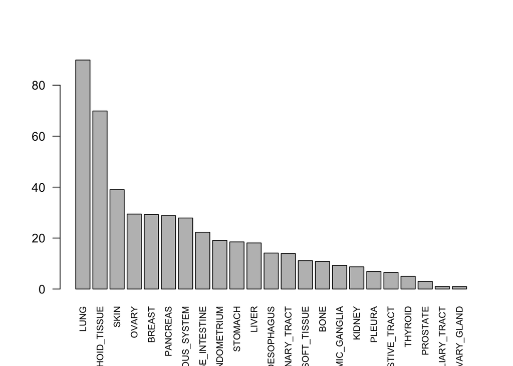

```r
counts <- table(sapply(strsplit(doseResponse$clName, "_"), function(x) paste(x[2:length(x)], collapse = "_")))
barplot(sort(decreasing = T,  counts / 24), las = 2, cex.names = .75)
```

```r
print(names(counts)[counts/ 24 > 20])
```

```
## [1] "BREAST"                             "CENTRAL_NERVOUS_SYSTEM"
## [3] "HAEMATOPOIETIC_AND_LYMPHOID_TISSUE" "LARGE_INTESTINE"
## [5] "LUNG"                               "OVARY"
## [7] "PANCREAS"                           "SKIN"
```

# 5 Generating (X, y, t)

Note that we can do this and all of the following analysis in a single loop. But since we may reuse the data multiple times for various experiment, we are going to do thise separately and save the results. X: measurements, y: response, t: cancer type.

```r
for(drug in unique(doseResponse$compound)){
  print(paste("Processing", drug))
  y <- doseResponse[doseResponse$compound == drug & doseResponse$clName %in% rownames(X), ]
  xyt <- as.data.frame(X[y$clName, ])
  xyt$yic50 <- y$ic50
  xyt$yaa <- y$actArea
  # extractCancerType
  xyt$t <- sapply(strsplit(y$clName, "_"), function(x) paste(x[2:length(x)], collapse = "_"))
  save(xyt, file = file.path(paths$clean, paste("xyt_", drug, ".Rda", sep = "")))
}
```

```
## [1] "Processing AEW541"
## [1] "Processing Nilotinib"
## [1] "Processing 17-AAG"
## [1] "Processing PHA-665752"
## [1] "Processing Lapatinib"
## [1] "Processing Nutlin-3"
## [1] "Processing AZD0530"
## [1] "Processing PF2341066"
## [1] "Processing L-685458"
## [1] "Processing ZD-6474"
## [1] "Processing Panobinostat"
## [1] "Processing Sorafenib"
## [1] "Processing Irinotecan"
## [1] "Processing Topotecan"
## [1] "Processing LBW242"
## [1] "Processing PD-0325901"
## [1] "Processing PD-0332991"
## [1] "Processing Paclitaxel"
## [1] "Processing AZD6244"
## [1] "Processing PLX4720"
## [1] "Processing RAF265"
## [1] "Processing TAE684"
## [1] "Processing TKI258"
## [1] "Processing Erlotinib"
```

Note that because of the way that we made X (from cell line tested at least against one drug) `doseResponse$clName` samples are for sure included in X. But then removed those with zero expression measurements. Therefore, we need the intersection. Also, note that I’m keeping cancer type as character not factor.